# Etude portant sur les limites à la durée de vie humaine par la théorie des valeurs extrêmes

UNIVERSITÉ DE LILLE

MAYENE Bienvenue Schekina

2023-01-23

# INTRODUCTION

Notre étude utilise un ensemble de données unique sur les âges au décès des français, décédés dans les années 1816 jusqu’à 2016. Celle-ci est basé sur la théorie des valeurs extrêmes , une approche cohérente des problèmes de recherche de ce type

La problématique principale est de savoir si le support de la distribution de probabilité de la variable aléatoire “durée de vie d’un être humain” a une extrémité droite finie

Notons que notre étude s’inspire de celle éffectué avec un ensemble de données unique sur les âges au décès - en jours - de tous (environ 285 000) résidents néerlandais, nés aux Pays-Bas, décédés dans les années 1986-2015 à un âge minimum de 92 ans

De ce fait, nous chercherons à obtenir dans un premier temps une base de données qui nous permettra de réaliser l’étude.

```r
# Chargement des packages
library(dplyr)
```

```r
library(tidyr)
library(evir)
library(ggplot2)
library(eva)
library(tea)
# Importation de la base

Base <- read.csv("~/Desktop/MASTER II MIASHS/APPRENTISSAGE_G_D/Mr_Sabbah/Deaths_France_Tot.txt", sep="")
View(Base)
```

Dans la présente étude, l’analyse a été effectuée séparément sur 30 années pour les femmes et les hommes. Nous allons donc deparer notre base de données et créer deux nouvelles bases qui nous afficheront les ages selon les 30 années que nous allons considerer pour notre étude.

Nous irons de l’année 1987 à l’année 2016 et nous considèrerons les personnes agés de 92 ans et plus .

```r
# Séparation Base des hommes et des femmes
Base_femme = select(Base,-c(4,5))
Base_homme = select(Base,-c(3,5))
```

# ETUDE POUR LES FEMMES

```r
## Création d'un tableau qui affiche les ages par années

maxis = c()
for(i in 1:30){
  data = subset(Base_femme, Year ==1986+i)
  maxis[i] = sum(data$Female[0:length(unique(data$Age))])
}
maxis
```

```
##  [1] 252107 252139 255019 253534 252119 250024 256583 249213 256510 258985
## [11] 257509 259810 262800 258821 258799 262135 273313 246341 256898 250607
## [21] 252817 260426 264194 265047 262318 277754 276964 271336 291134 290976
```

```r
Base_femme2 = matrix(ncol= length(unique(Base_femme$Year)),
                     nrow= max(maxis))

for(i in 1:length(unique(Base_femme$Year))){
  data2 = subset(Base_femme, Year == 1986+ i)
  data2 = subset(data2, Age>= 92)
  Base_femme2[, i]= rep(c(unique(data2$Age), NA), c(data2$Female[0:length(unique(data2$Age))], max(maxis)- sum(data2$Female[0:length(unique(data2$Age))])))

}
```

La base de données que nous avons obtenue nous donne les ages en année. Nous allons convertir ces ages en jours de la manière suivante :

```r
# convertissons la table ages en jour
Base_femme2 = Base_femme2*365
```

## Les extrémités des distributions de durée de vie sont-elles finies ?

Premièrement nous allons calculer avec la commande “gpd” issue du package “Evir les principales estimations. Il s’agira de :

- les indices estimés des valeurs extrêmes (pour chaque année)
- les échelles estimées (scale a)
- Le seuil (the threshold)

```r
### Utilisation de la commande gpd pour extraire les indices

vector1 <-c()
vector2 <-c()
vector3 <-c()

for(i in 1:30){
  table1w = Base_femme2[, i]
  table1w = na.omit(table1w)
  a <- gpd(table1w, nextremes=1500, method = c("ml"))
  vector1 <- append(vector1,a$threshold) #treshold in days vector 1
  vector2 <- append(vector2,a$par.ests[1]) #gamma ou xi vector 2
  vector3 <- append(vector3,a$par.ests[2]) #scala_a vector 3
}
```

Représentation graphique

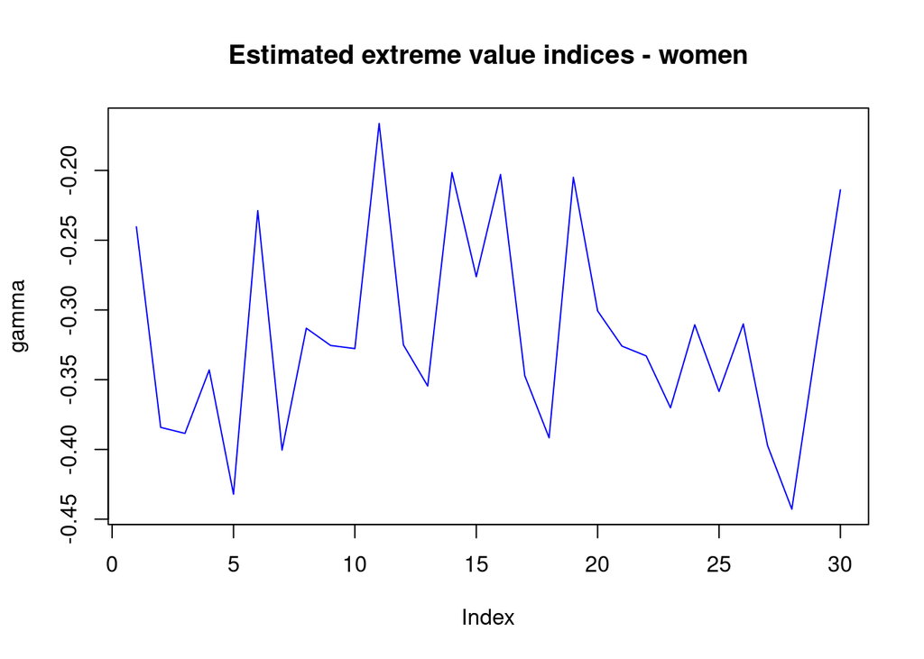

```r
plot(vector2,type="l" , ylab= "gamma", main = "Estimated extreme value indices - women", col= "blue")
```

Les indices de valeurs extrêmes estimés sont présentés dans figure ci-dessus. Il est clair qu’ils sont tous négatifs et cela fait allusion à un critère supérieur fini, c’est-à- dire une durée de vie maximale finie. Ici, pour les femmes cet indice maximum estimé est celui correspondant à l’année 1997 et il est égal à :

```r
max(vector2)
```

```
## [1] -0.1663251
```

Nous développons un test pour l’hypothèse nulle selon laquelle au moins un des 30 indices de valeurs extrêmes est non négatif par rapport à l’alternative qu’ils sont tous négatifs, avec un niveau de significativité de 5 %.

Rappelons qu’un indice de indices de valeurs extrêmes négatif implique une extrémité supérieure finie de la distribution.

Le test est basé sur le maximum des indices de valeurs extrêmes estimées. Il conduit à une p-value de 5,94e⁻¹¹.

cette valeur est obtenue en faisant le calcul suivant : Soit la fonction phi, la fonction de distribution normale standard.

Nous avons donc determiner la valeur de phi(-0,1663*sqrt(1500)) qui est égal à 5,94e⁻¹¹.

Ce test établit alors que la limite supérieure de la distribution de probabilité de la durée de vie humaine des femmes françaises sont finies pour l’ensemble des 30 années considérées.

## Quel est le point limite supérieur de la distribution de la durée de vie ?

```r
## calcul des autres indices

#treshold
treshold_year <- c()
for(i in 1:30){
  treshold_year[i] = vector1[i]/365.25
}
```

```r
#oldest
oldest <- c()
for(i in 1:30){
    data = subset(Base_femme, Year ==1986+i)
    oldest[i] = max(data$Age[0: length(data$Age)])
}
```

```r
omega <- c()
for(i in 1:30){
  omega[i] = ((vector1[i]-vector3[i]/vector2[i])/365.25)
}
```

```r
# 95% upper confidence bound for omega
omega95 <- c()
for(i in 1:30){
  omega95[i] = omega[i]+ ((1.64485363*(vector3[i]/365.25))*sqrt(1+ 4*vector2[i]+ 5*(vector2[i])^2 + 2*(vector2[i])^3 + 2*(vector2[i])^4))/(sqrt(1500)*vector2[i]^2)
}
```

Rappel : treshold in days : vector 1 gamma: vector 2 scala_a: vector 3

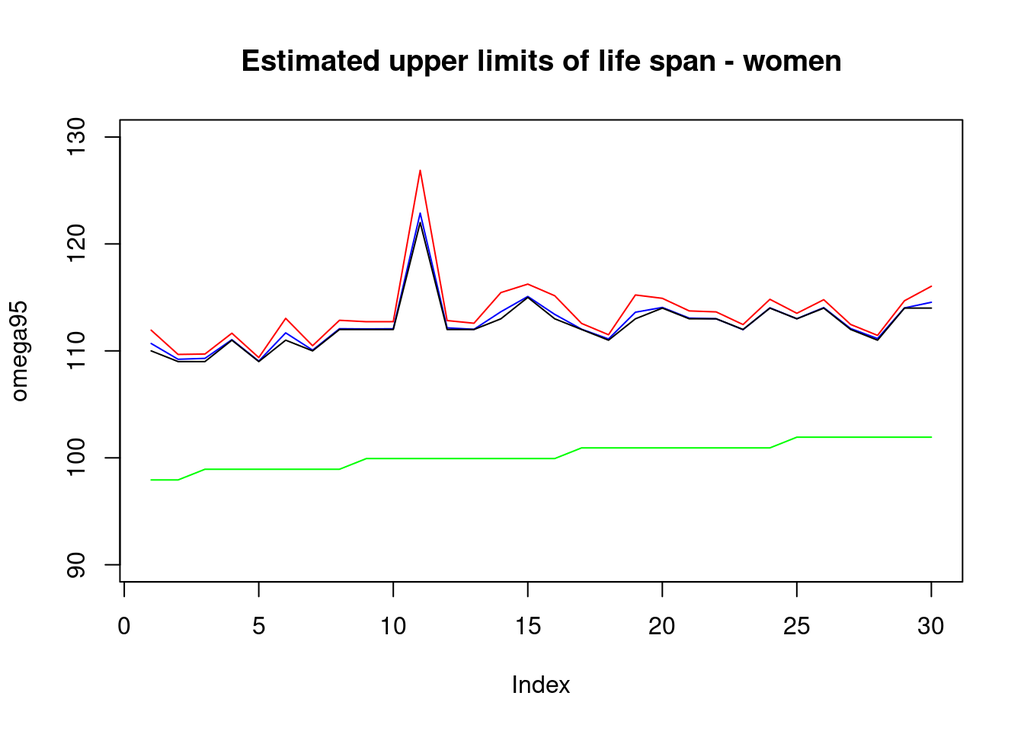

```r
# Graphique numero 2
plot(omega95, type = "l" , col = "red", ylim=c(90,130), main = "Estimated upper limits of life span - women")
lines(omega, col = "blue")
lines(oldest, col = "black")
lines(treshold_year, col = "green")
```

Nous pouvons voir 4 lignes dans le graphique ci-dessus. - La ligne bleue représente les points finaux supérieurs estimés en années - La ligne rouge montre la partie supérieure unilatérale à 95% de borne de confiance pour chaque année indiquant ainsi le niveau d’incertitude dans l’estimation.

```r
mean(omega)
```

```
## [1] 112.6068
```

```r
max(omega)
```

```
## [1] 122.8831
```

```r
mean(omega95)
```

```
## [1] 113.5057
```

```r
mean(oldest)
```

```
## [1] 112.4
```

```r
min(treshold_year)
```

```
## [1] 97.93292
```

```r
max(treshold_year)
```

```
## [1] 101.9302
```

- La ligne noir indique l’age de la personne la plus âgée à décéder chaque année
- ligne verte indique l’âge de la 1500e personne la plus âgée à décéder chaque année

En d’autres termes, nous voyons que la distribution de probabilité à un âge élevé se déplace vers le critère d’évaluation, au fil des ans, mais que les critères d’évaluation eux-mêmes n’augmentent pas.

# Existe-t-il une tendance dans la durée maximale de la vie humaine ?

```r
vector3_bis<- c()

for(i in 1:30){
  vector3_bis[i] = vector3[i]/365.25
}
```

```r
#Création d'un tableau avec tous les indices calculés

tableau_indicew <- data.frame(treshold_days = vector1, gamma = vector2, scale_a = vector3, treshold_year, oldest, omega, omega95 ,scale_a_y = vector3_bis)
```

```r
#ggplot(tableau_indicew, aes(x=seq(1:30), y=scale_a_y)) +
#  geom_point(shape=23, fill="blue", color="darkred", size=1) +
#  geom_smooth(method=lm, se=FALSE) + ggtitle("Estimated Scales - #Woman")
```

```r
typeof(tableau_indicew)
```

```
## [1] "list"
```

J’ai eu à rencontrer des difficultés à effectuer un graphique avec la librairie ggplot2 alors que le code fonctionait auparavant.

Le plus étranger c’est le type de la base de données tableau_indicew qui est “list” tandis que c’est sensé etre un dataframe.

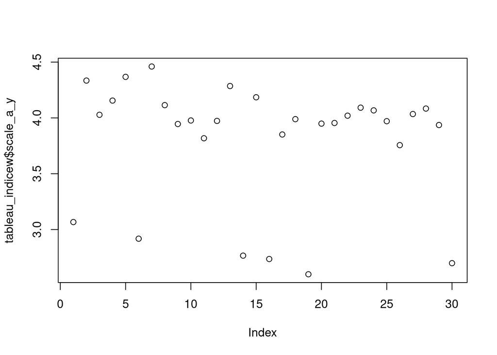

```r
plot(tableau_indicew$scale_a_y)
```

L’inspection visuelle ne révèle aucune tendance dans les estimations des paramètres pour les femmes.

# ETUDE POUR LES HOMMES

```r
## Création d'un tableau qui affiche les ages par années

maxis = c()
for(i in 1:30){
  data = subset(Base_homme, Year ==1986+i)
  maxis[i] = sum(data$Male[0:length(unique(data$Age))])
}
maxis
```

```
##  [1] 275360 272454 274262 272663 272559 271505 275677 270748 275105 276789
## [11] 272807 274193 274860 272043 272274 273007 279022 263087 270635 265809
## [21] 268206 271697 273916 275414 272468 281468 281426 275656 290621 290091
```

```r
Base_homme2 = matrix(ncol= length(unique(Base_homme$Year)),
                     nrow= max(maxis))


for(i in 1:length(unique(Base_homme$Year))){
  data2 = subset(Base_homme, Year == 1986+ i)
  data2 = subset(data2, Age>= 92)
  Base_homme2[, i]= rep(c(unique(data2$Age), NA), c(data2$Male[0:length(unique(data2$Age))], max(maxis)- sum(data2$Male[0:length(unique(data2$Age))])))

}
```

Comme nous l’avons fait précédemment nous allons convertir les ages de la base Base_homme2 en jours.

```r
# convertissons la table ages en jour
Base_homme2 = Base_homme2*365.25
```

# Calcul des principales estimations.

```r
### Utilisation de la commande gpd pour extraire les indices

vector1M <-c()
vector2M <-c()
vector3M <-c()

for(i in 1:30){
  table1w = Base_homme2[, i]
  table1w = na.omit(table1w)
  a <- gpd(table1w, nextremes=1500, method = c("ml"))
  vector1M <- append(vector1M,a$threshold) #treshold in days vector 1
  vector2M <- append(vector2M,a$par.ests[1]) #gamma ou xi vector 2
  vector3M <- append(vector3M,a$par.ests[2]) #scala_a vector 3
}
```

Représentation graphique

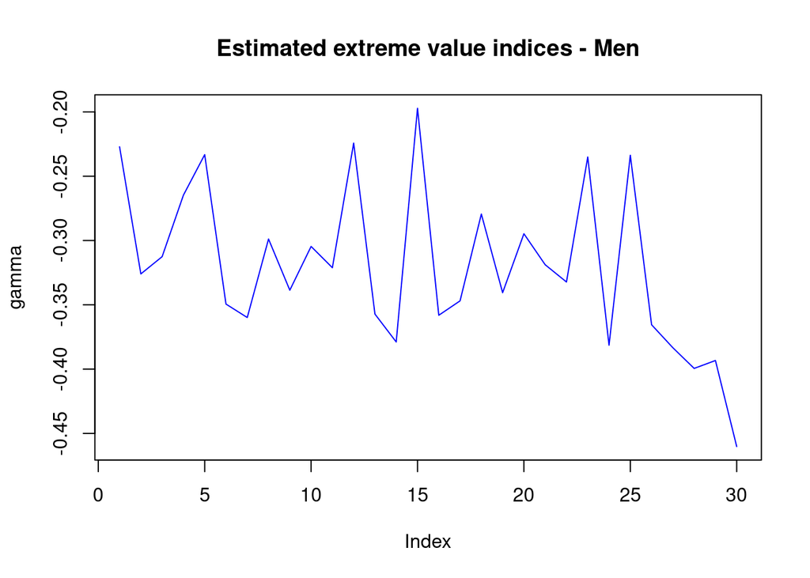

```r
plot(vector2M,type="l" , ylab= "gamma", main = "Estimated extreme value indices - Men", col= "blue")
```

Les indices de valeurs extrêmes estimés sont présentés dans figure ci-dessus. Il est clair qu’ils sont tous négatifs et cela fait allusion à un critère supérieur fini, c’est-à- dire une durée de vie maximale finie. Ici, pour les hommes cet indice maximum estimé est celui correspondant à l’année 2001 et il est égal à :

```r
max(vector2M)
```

```
## [1] -0.1972036
```

Comme précedemment nous développons un test pour l’hypothèse nulle selon laquelle au moins un des 30 indices de valeurs extrêmes est non négatif par rapport à l’alternative qu’ils sont tous négatifs, avec un niveau de significativité de 5 %.

## Limite supérieur de la distribution de la durée de vie

```r
## calcul des autres indices
#
treshold_yearM <- c()
for(i in 1:30){
  treshold_yearM[i] = vector1M[i]/365.25
}
```

```r
#oldest
oldestM <- c()
for(i in 1:30){
  data = subset(Base_homme, Year ==1986+i)
  oldestM[i] = max(data$Age[0: length(data$Age)])
}
```

```r
omegaM <- c()
for(i in 1:30){
  omegaM[i] = ((vector1M[i]-vector3M[i]/vector2M[i])/365.25)
}
```

```r
# 95% upper confidence bound for omega
omega95M <- c()
for(i in 1:30){
  omega95M[i] = omegaM[i]+ ((1.64485363*(vector3M[i]/365.25))*sqrt(1+ 4*vector2M[i]+ 5*(vector2M[i])^2 + 2*(vector2M[i])^3 + 2*(vector2M[i])^4))/(sqrt(1500)*vector2M[i]^2)
}
```

Rappel : treshold in days : vector 1 gamma: vector 2 scala_a: vector 3

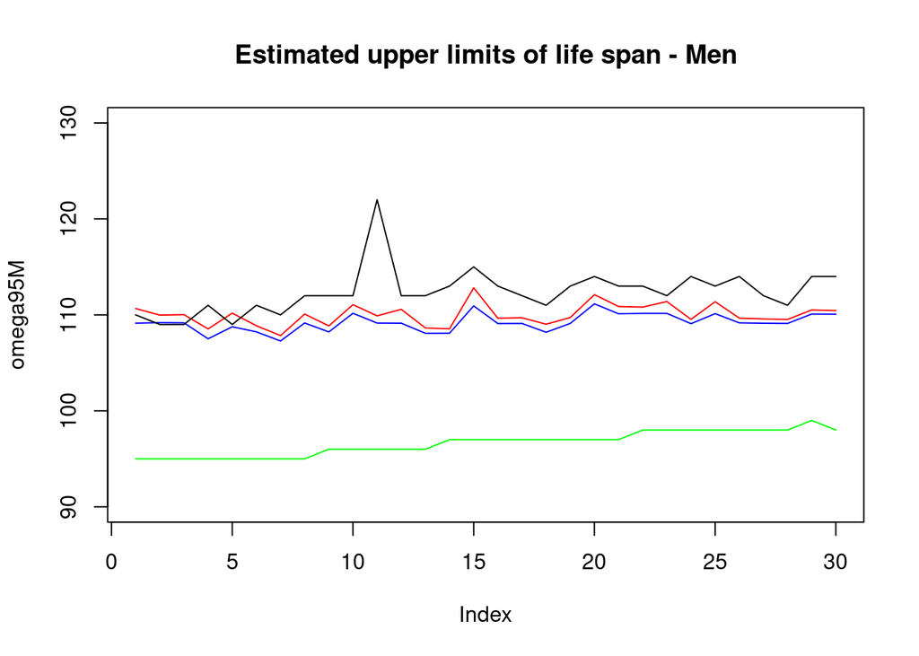

```r
# Graphique numero 2
plot(omega95M, type = "l" , col = "red", ylim=c(90,130), main = "Estimated upper limits of life span - Men")
lines(omegaM, col = "blue")
lines(oldestM, col = "black")
lines(treshold_yearM, col = "green")
```

Nous pouvons voir 4 lignes dans le graphique ci-dessus. - La ligne bleue représente les points finaux supérieurs estimés en années - La ligne rouge montre la partie supérieure unilatérale à 95% de borne de confiance pour chaque année indiquant ainsi le niveau d’incertitude dans l’estimation.

```r
mean(omegaM)
```

```
## [1] 109.2024
```

```r
max(omegaM)
```

```
## [1] 111.1521
```

```r
mean(omega95M)
```

```
## [1] 110.0155
```

```r
mean(oldestM)
```

```
## [1] 112.4
```

```r
min(treshold_yearM)
```

```
## [1] 95
```

```r
max(treshold_yearM)
```

```
## [1] 99
```

Le critère supérieur moyen estimé est de 109.2 ans et le critère supérieur estimé maximum,correspondant à l’année 2006, est de 111.2 ans La moyenne des bornes supérieures de confiance est de 110 ans.

En d’autres termes, nous voyons que la distribution de probabilité à un âge élevé se déplace vers le critère d’évaluation, au fil des ans, mais que les critères d’évaluation eux-mêmes n’augmentent pas.

# Tendance dans la durée maximale de la vie humaine ?

```r
# Graphique numero3

vector3_bisM<- c()

for(i in 1:30){
  vector3_bisM[i] = vector3M[i]/365.25
}
```

```r
tableau_indiceM <- data.frame(treshold_days = vector1M, gamma = vector2M, scale_a = vector3M, treshold_yearM, oldestM, omegaM, omega95M ,scale_a_y = vector3_bisM)
```

```r
#ggplot(tableau_indiceM, aes(x=seq(1:30), y=scale_a_y)) +
#  geom_point(shape=23, fill="blue", color="darkred", size=1) +
#  geom_smooth(method=lm, se=FALSE) + ggtitle("Estimated Scales - #Woman")
```

Meme problème obtenu dans le cadre de l’étude des femmes

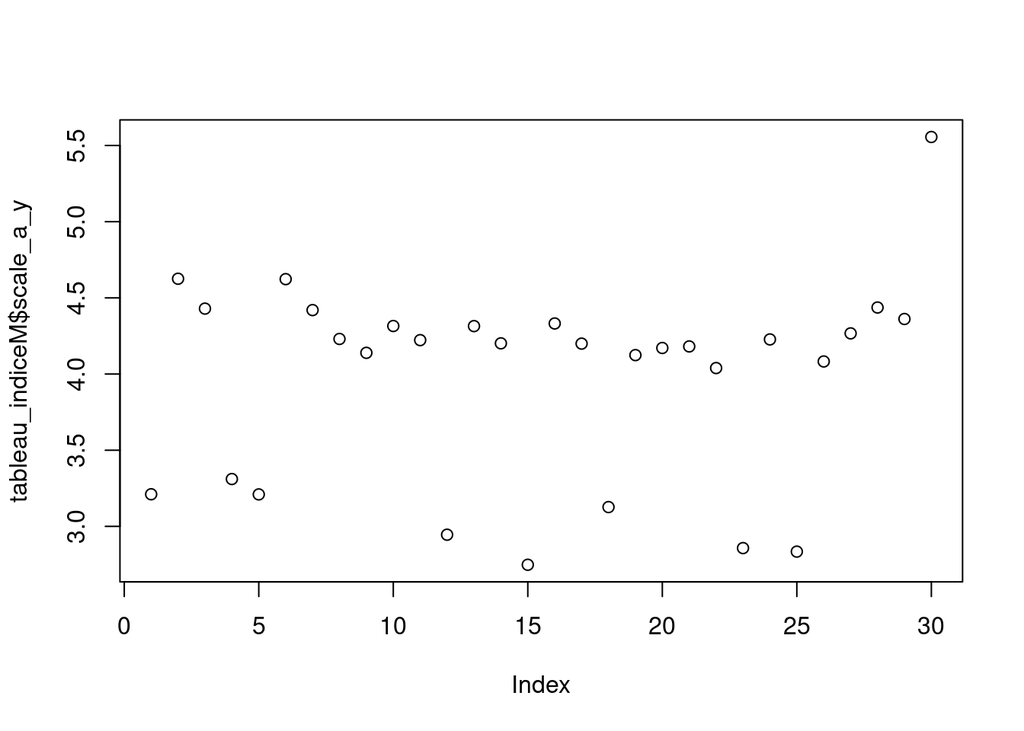

```r
plot(tableau_indiceM$scale_a_y)
```

L’inspection visuelle ne révèle aucune tendance dans les estimations des paramètres pour les hommes